# Data base Law Enforcement Reports Sea Turtles

Hernán G. Álvarez and Jessica Kahler

2024-06-30

# 2018 and 2022 Law Enforcement Reports Database

- The following data set contains information extracted from the weekly law enforcement reports created by the Division of Law Enforcement of the Florida Wildlife Commission (FWC). The data was downloaded from the following website: https://myfwc.com/about/inside-fwc/le/weekly-reports/
- Law enforcement activities are divided in 5 main regions. Each regions has its own representatives. The following data set can be explored within each region.

**Map showing the 5 main regions in the State of Florida**

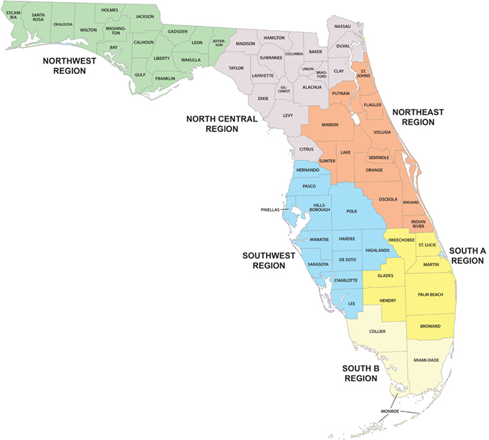

# Data set

The following table shows a sample of the databased.

| Record_ID | Report_type | Year | Date | Florida_regions | Enforcement_events | Locations | Report_text |
| --- | --- | --- | --- | --- | --- | --- | --- |
| 2 | Enforcement_report | 2018 | apr20_26 | NORTHWEST REGION | CASES | FRANKLIN COUNTY | Officers Richardson and Sauls were conducting an oyster detail in the Eastpoint Area. They saw a vessel returning from oystering. As the vessel approached the ramp the officers saw a female subject on… |
| 3 | Enforcement_report | 2018 | apr20_26 | NORTHWEST REGION | CASES | SANTA ROSA COUNTY | Officer Wilkenson was on vessel patrol conducting boating safety and fisheries inspections in the Intracoastal Waterway (Santa Rosa Sound) near the Navarre causeway. The officer saw a vessel with two … |
| 4 | Enforcement_report | 2018 | apr20_26 | NORTHWEST REGION | CASES | WALTON COUNTY | Officer White was patrolling Eglin Air Force Base Wildlife Management Area and discovered subjects hunting in a closed portion of the Choctaw East Unit. Officer White identified three subjects that ha… |
| 5 | Enforcement_report | 2018 | apr20_26 | NORTHWEST REGION | COMMUNITY ORIENTED POLICING | OKALOOSA COUNTY | Officers Brooks and Rockwell attended an outdoor education class for Baker High School. The officers brought a vessel and talked about the importance of boating safety and life jackets with the upcomi… |
| 6 | Enforcement_report | 2018 | apr20_26 | NORTHWEST REGION | COMMUNITY ORIENTED POLICING | SANTA ROSA COUNTY | Officer Land had a vessel on display at shoreline park where he interacted with over 120 students from Gulf Breeze Middle School. Officer Land educated students about the role and responsibilities of … |
| 7 | Enforcement_report | 2018 | apr20_26 | NORTH CENTRAL REGION | CASES | MADISON COUNTY | Officer Vazquez while on foot patrol discovered a blind within 100 yards of an active feeder towards the end of spring turkey season. On the last weekend of the season Officer Vazquez saw a subject en… |
| 8 | Enforcement_report | 2018 | apr20_26 | NORTH CENTRAL REGION | SEARCH AND RESCUE | CITRUS COUNTY | Officers Canfield and Browning responded to a medical emergency aboard a vessel offshore of Citrus County. While in route, they met with a Citrus County Fire Rescue boat and took a firefighter/EMT abo… |
| 9 | Enforcement_report | 2018 | apr20_26 | NORTH CENTRAL REGION | DIRECTED CONSERVATION PATROLS | CITRUS COUNTY | The Offshore Patrol Vessel (OPV) 2005 Fincat, with Officers Canfield, Boyer and Willis deployed from Crystal River to the Naples/Key West area to conduct turtle excluder device (TED) enforcement on co… |
| 10 | Enforcement_report | 2018 | apr20_26 | NORTH CENTRAL REGION | COMMUNITY ORIENTED POLICING | SUWANNEE COUNTY | Officer Boone participated in the law portion of a Hunter Education class in Live Oak. There were several students with parents in attendance for the class. Numerous questions were answered on the top… |
| 11 | Enforcement_report | 2018 | apr20_26 | NORTHEAST REGION | CASES | LAKE COUNTY | Officer Morrow and Reserve Officer Baugh received a call of an owl entangled in fishing lines and hooks in Tavares. The officers climbed into a tree and were able to rescue the bird. The bird was take… |
| 12 | Enforcement_report | 2018 | apr20_26 | NORTHEAST REGION | EMERGENCY RESPONSE OR SERVICES | MARION COUNTY | Officers, investigators, lieutenants, captains and Major Russel in the Northeast Region responded to Forest High School in Ocala regarding shots being fired in the school. The officers assisted the Ma… |
| 13 | Enforcement_report | 2018 | apr20_26 | NORTHEAST REGION | COMMUNITY ORIENTED POLICING | PUTNAM COUNTY | Officer Wester set up an outreach display at Dunn’s Creek State Park for Earth Day. There were approximately 200 people in attendance. |
| 14 | Enforcement_report | 2018 | apr20_26 | NORTHEAST REGION | COMMUNITY ORIENTED POLICING | LAKE COUNTY | Officer Morrow and Reserve Officer Baugh assisted FWC and Forestry with their Welcome to the Woods event at Seminole State Forest. The event had over 80 children in attendance. The officers taught abo… |
| 15 | Enforcement_report | 2018 | apr20_26 | SOUTHWEST REGION | CASES | HILLSBOROUGH COUNTY | Officer Gonzales was on land patrol around Lavender Road. While on patrol he discovered several individuals had illegally entered South West Florida Water Management District property to fish. Officer… |
| 16 | Enforcement_report | 2018 | apr20_26 | SOUTHWEST REGION | CASES | LEE COUNTY | While on offshore patrol in the Gulf of Mexico, Lieutenant Spoede and Officers Winton and Fogle saw a fishing vessel transiting in from offshore waters. The officers conducted a vessel stop and discov… |
| 17 | Enforcement_report | 2018 | apr20_26 | SOUTHWEST REGION | CASES | MANATEE COUNTY | Officer Davidson was on land patrol around Pappi‚Äôs Cut near Perico Bayou. While on patrol he stopped and performed a fisheries inspection on a group of men that were cast netting fish in Perico Bayo… |
| 18 | Enforcement_report | 2018 | apr20_26 | SOUTHWEST REGION | CASES | PINELLAS COUNTY | Officer Pettifer received a call regarding individuals placing baited turtle traps in a freshwater lake near Clearwater. Officer Pettifer responded at the beginning of his shift and located the net. T… |
| 19 | Enforcement_report | 2018 | apr20_26 | SOUTHWEST REGION | CASES | SARASOTA COUNTY | Officer Brown was on land patrol around the Stickney Point Bridge. He performed a fisheries inspection on two individuals fishing from the bridge. During the inspection it was found that the individua… |
| 20 | Enforcement_report | 2018 | apr20_26 | SOUTH REGION A | CASES | BROWARD COUNTY | Officer Sullivan was patrolling US 27 when he saw an individual fishing at a spillway. He stopped to conduct a fisheries inspection. The subject had 3 black bass, all over 16 inches. A records check s… |
| 21 | Enforcement_report | 2018 | apr20_26 | SOUTH REGION A | CASES | GLADES COUNTY | Officer Brodbeck was on patrol in Lakeport when he saw a vehicle with no license plate traveling westbound on SR 78. He initiated a vehicle stop to address the violation. The officer recognized the dr… |
| 22 | Enforcement_report | 2018 | apr20_26 | SOUTH REGION A | CASES | HENDRY COUNTY | Officer Brodbeck was on patrol in the Okaloacoochee Slough State Forest when he saw a vehicle on CR 832. After observing the vehicle for several minutes, a vehicle stop was initiated. The driver of th… |
| 23 | Enforcement_report | 2018 | apr20_26 | SOUTH REGION A | CASES | MARTIN COUNTY | Officer Willems was dispatched to a 911 call for a suicidal subject at Dupuis Wildlife Management Area (WMA) campground. Once on scene, the individual was questioned about the call and it was verified… |
| 24 | Enforcement_report | 2018 | apr20_26 | SOUTH REGION A | CASES | PALM BEACH COUNTY | Officers Merizio and Brevik were patrolling the Corbett WMA. While on patrol the officers saw approximately 10 trucks and trailers parked at stumpers grade and the powerlines (trail 11). The trailers … |
| 25 | Enforcement_report | 2018 | apr20_26 | SOUTH REGION A | CASES | ST. LUCIE COUNTY | Investigator Patterson and Officer Payne responded to an anonymous tip regarding illegal fishing at Belcher Canal Spillway. Belcher Canal Spillway is a designated construction site that is fenced and … |
| 26 | Enforcement_report | 2018 | apr20_26 | SOUTH REGION A | SEARCH AND RESCUE | MARTIN COUNTY | Lieutenant Fillip and Officers Merizio, Kirkland, Trawinski, Brevik, Carroll, and Defeo responded to a search and rescue in the Hungryland Wildlife Environmental Area. The call came from the Martin Co… |
| 27 | Enforcement_report | 2018 | apr20_26 | SOUTH REGION A | SEARCH AND RESCUE | PALM BEACH COUNTY | Officer Merizio assisted FHP and Palm Beach County Fire Rescue with a 2-vehicle accident on I-95 near Hypoluxo road. Officer Merizio saw a vehicle on the side of the road smoking with a police vehicle… |
| 28 | Enforcement_report | 2018 | apr20_26 | SOUTH REGION A | WILDLIFE RESPONSE, ASSISTANCE AND RESCUE | MARTIN COUNTY | Officers Carroll and Brevik were on water patrol when they received a call regarding an injured bird on the Stuart sandbar. The officers located the royal tern standing on the sandbar. When the tern w… |
| 29 | Enforcement_report | 2018 | apr20_26 | SOUTH REGION A | WILDLIFE RESPONSE, ASSISTANCE AND RESCUE | ST. LUCIE COUNTY | Officer Morrow responded to a report of a bird in distress in Coastal St. Lucie County. Upon arrival, the officer located the bird, which was determined to be a gannet. The gannet was removed from the… |
| 30 | Enforcement_report | 2018 | apr20_26 | SOUTH REGION A | COMMUNITY ORIENTED POLICING | PALM BEACH COUNTY | Officer Mann attended an educational event for disabled high school students at Macarthur Beach State Park. Officer Mann met with the kids and answered any questions they had about the agency and cons… |
| 31 | Enforcement_report | 2018 | apr20_26 | SOUTH REGION B | CASES | COLLIER COUNTY | Officer Yurewitch and Investigator White were on water patrol in Wiggin‚Äôs Pass when they saw a PWC operating on plane in a posted manatee zone. When the officers stopped the PWC they saw signs of im… |

[output cut: 70 more lines]

# Descriptive Statistics

### *Distribution Enforcement Events*

The law enforcement reports are divided by different enforcement activities. Within those activities, reporting cases was the most frequent activity (>60%), followed by community-oriented policing, search and rescue, expanding participation in conservation, directed conservation patrols, and major wildlife assistance. The following graph shows the distribution of the different law enforcement activities done between 2018 and 2022 across the different Florida regions.

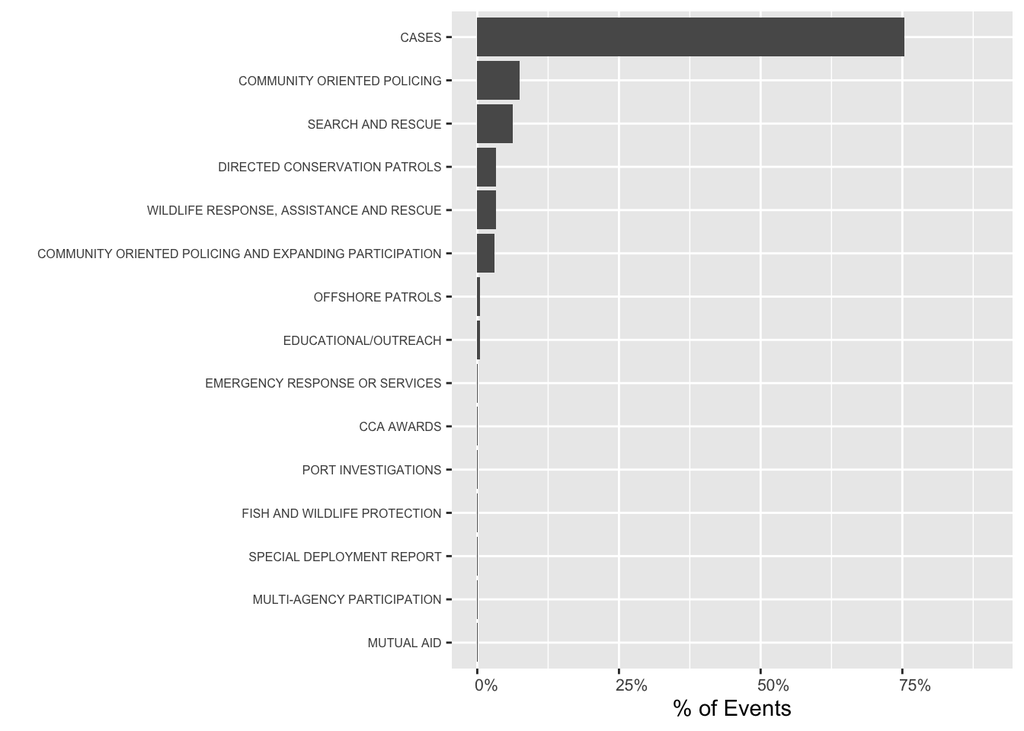

### *Enforcement Events by Regions*

The following graph shows the distribution of enforcement events in the different regions of Florida. Northwest region has most cases reported, while South Region B has the lowest cases reported.

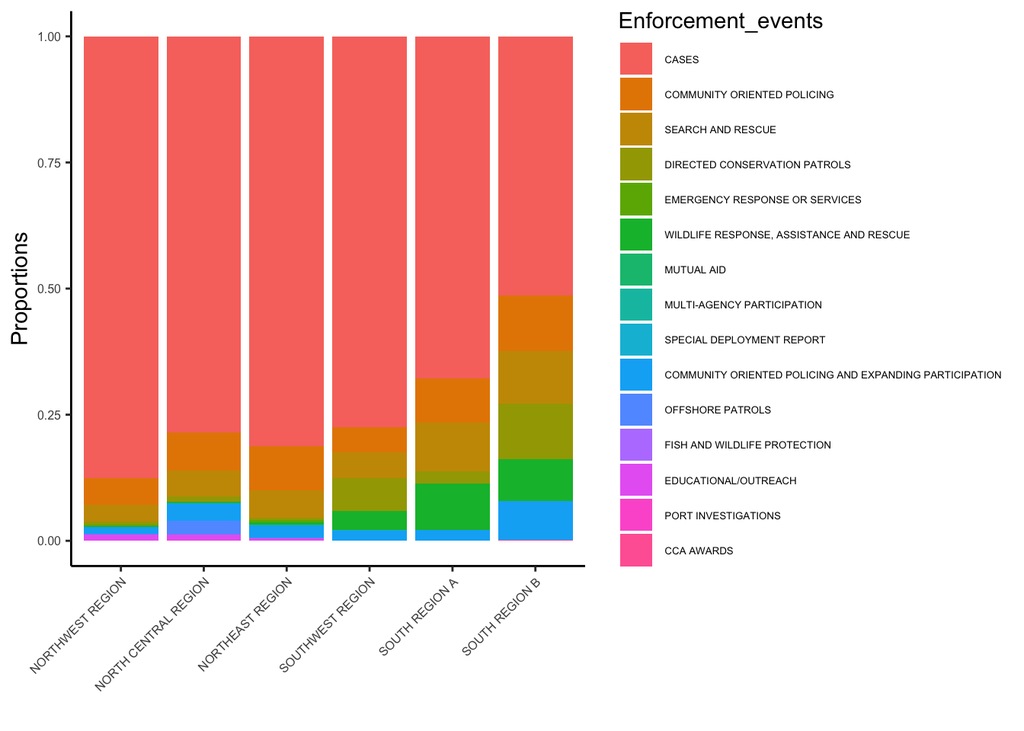

# Enforcement reports for Turtles

Out of 6749 law enforcement reports, 150 (2.2%) reports mention something about turtles.

## *What are the Florida regions with more law enforcement reports about turtles?*

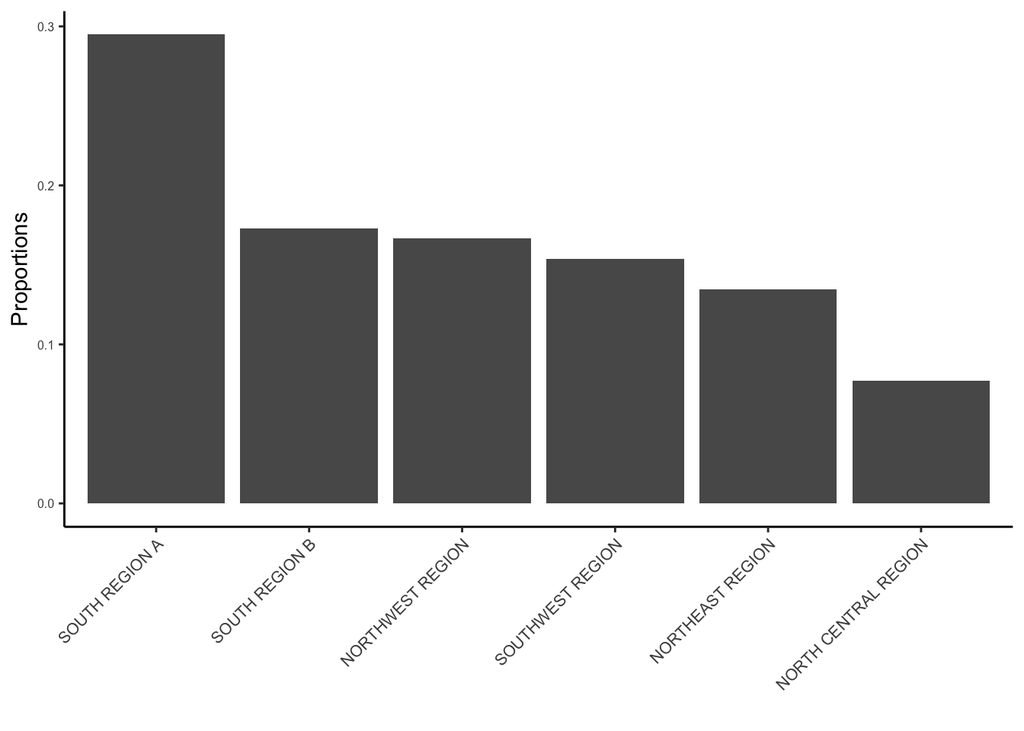

## *What are the law enforcement events are related to turtles?*

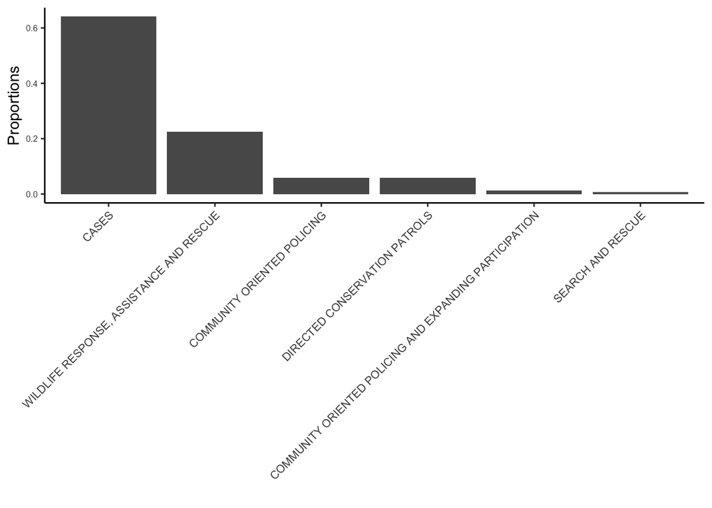

## *What are the most frequent words in the law enforcement reports related to turtles?*

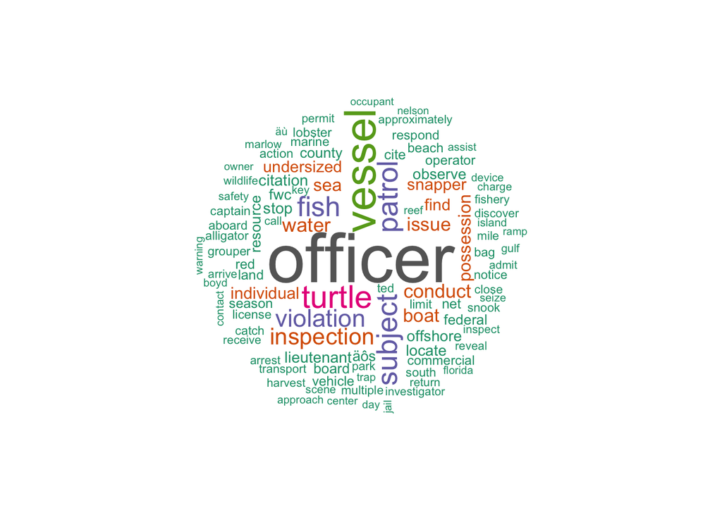